# project_eda

## Load Spark

```python
spark
```

```
StatementMeta(f97af3eb-5425-4080-aefb-36c5e3ecc371, 15, 6, Finished, Available)
```

**SparkSession - hive**

**SparkContext**

[Spark UI](http://vm-3ed60162:41449)

**Version**

`v3.2.2.5.1-100879434`

**Master**

`yarn`

**AppName**

`Azure ML Experiment`

### 3 EDA Business Goals

#### 1. Subreddit Activity and Engagement Levels

**Business Goal:** Identify the most active subreddits to target content and ads effectively, increasing engagement and reach.

**Technical Proposal:** Analyze the frequency of posts and comments per subreddit to rank the subreddits by activity. Use visualizations like heatmaps to display peak activity times and days, and calculate engagement rates by considering the number of upvotes, comments, and shares relative to the number of subscribers.

#### 2. Trend Analysis of Topics Over Time

**Business Goal:** Understand shifting trends in subreddit topics to inform content strategy and stay ahead of market interests.

**Technical Proposal:** Perform a time-series analysis of keywords and phrases from submissions and comments. Use topic modeling to identify emerging topics and trends over time. Visualize the data using line charts to show the ebb and flow of various topics.

#### 3. User Participation Patterns

**Business Goal:** Optimize community interaction by understanding the patterns in user participation and tailoring engagement strategies accordingly.

**Technical Proposal:** Investigate user participation across different subreddits by tracking metrics such as number of posts, comments, and upvotes. Segment users into cohorts based on activity levels and visualize their participation over time using cohort analysis. Determine the retention and churn rates of users to identify what drives sustained engagement within subreddits.

## Get Data from Datastore

```python
blob_account_name = "marckvnonprodblob"
blob_container_name = "bigdata"
# read only
blob_sas_token = "?sv=2021-10-04&st=2023-10-04T01%3A42%3A59Z&se=2024-01-02T02%3A42%3A00Z&sr=c&sp=rlf&sig=w3CH9MbCOpwO7DtHlrahc7AlRPxSZZb8MOgS6TaXLzI%3D"

wasbs_base_url = (
    f"wasbs://{blob_container_name}@{blob_account_name}.blob.core.windows.net/"
)
spark.conf.set(
    f"fs.azure.sas.{blob_container_name}.{blob_account_name}.blob.core.windows.net",
    blob_sas_token,
)
```

```
StatementMeta(f97af3eb-5425-4080-aefb-36c5e3ecc371, 15, 7, Finished, Available)
```

### Collect data from Aug, 2022

```python
comments_path = "reddit-parquet/comments/"
submissions_path = "reddit-parquet/submissions/"
comments_month = "year=2022/month=8/"
submissions_month = "year=2022/month=8/"
```

```
StatementMeta(f97af3eb-5425-4080-aefb-36c5e3ecc371, 15, 10, Finished, Available)
```

```python
comments_aug_df = spark.read.parquet(f"{wasbs_base_url}{comments_path}{comments_month}")
submissions_aug_df = spark.read.parquet(f"{wasbs_base_url}{submissions_path}{submissions_month}")
```

```
StatementMeta(f97af3eb-5425-4080-aefb-36c5e3ecc371, 15, 17, Finished, Available)
```

Filter data to keep memes only

```python
submissions_filtered = submissions_aug_df.filter(submissions_aug_df.subreddit == "memes")
comments_filtered = comments_aug_df.filter(comments_aug_df.subreddit == "memes")
```

```
StatementMeta(f97af3eb-5425-4080-aefb-36c5e3ecc371, 15, 18, Finished, Available)
```

```python
submissions_meme = submissions_aug_df.filter(submissions_aug_df.subreddit == "memes")
comments_meme = comments_aug_df.filter(comments_aug_df.subreddit == "memes")
```

```
StatementMeta(f97af3eb-5425-4080-aefb-36c5e3ecc371, 15, 63, Finished, Available)
```

Keep the data size under 10,000

```python
sub_df = submissions_filtered.limit(10000).cache()
com_df = comments_filtered.limit(10000).cache()
```

```
StatementMeta(f97af3eb-5425-4080-aefb-36c5e3ecc371, 15, 23, Finished, Available)
```

## Initial Exploration

Report on the basic info about your dataset. What are the interesting columns? What is the schema? How many rows do you have? etc. etc.

```python
com_df.printSchema()
```

```
StatementMeta(f97af3eb-5425-4080-aefb-36c5e3ecc371, 15, 26, Finished, Available)
```

```
root
 |-- author: string (nullable = true)
 |-- author_cakeday: boolean (nullable = true)
 |-- author_flair_css_class: string (nullable = true)
 |-- author_flair_text: string (nullable = true)
 |-- body: string (nullable = true)
 |-- can_gild: boolean (nullable = true)
 |-- controversiality: long (nullable = true)
 |-- created_utc: timestamp (nullable = true)
 |-- distinguished: string (nullable = true)
 |-- edited: string (nullable = true)
 |-- gilded: long (nullable = true)
 |-- id: string (nullable = true)
 |-- is_submitter: boolean (nullable = true)
 |-- link_id: string (nullable = true)
 |-- parent_id: string (nullable = true)
 |-- permalink: string (nullable = true)
 |-- retrieved_on: timestamp (nullable = true)
 |-- score: long (nullable = true)
 |-- stickied: boolean (nullable = true)
 |-- subreddit: string (nullable = true)
 |-- subreddit_id: string (nullable = true)
```

```python
sub_df.printSchema()
```

```
StatementMeta(f97af3eb-5425-4080-aefb-36c5e3ecc371, 15, 27, Finished, Available)
```

```
root
 |-- adserver_click_url: string (nullable = true)
 |-- adserver_imp_pixel: string (nullable = true)
 |-- archived: boolean (nullable = true)
 |-- author: string (nullable = true)
 |-- author_cakeday: boolean (nullable = true)
 |-- author_flair_css_class: string (nullable = true)
 |-- author_flair_text: string (nullable = true)
 |-- author_id: string (nullable = true)
 |-- brand_safe: boolean (nullable = true)
 |-- contest_mode: boolean (nullable = true)
 |-- created_utc: timestamp (nullable = true)
 |-- crosspost_parent: string (nullable = true)
 |-- crosspost_parent_list: array (nullable = true)
 |    |-- element: struct (containsNull = true)
 |    |    |-- approved_at_utc: string (nullable = true)
 |    |    |-- approved_by: string (nullable = true)
 |    |    |-- archived: boolean (nullable = true)
 |    |    |-- author: string (nullable = true)
 |    |    |-- author_flair_css_class: string (nullable = true)
 |    |    |-- author_flair_text: string (nullable = true)
 |    |    |-- banned_at_utc: string (nullable = true)
 |    |    |-- banned_by: string (nullable = true)
 |    |    |-- brand_safe: boolean (nullable = true)
 |    |    |-- can_gild: boolean (nullable = true)
 |    |    |-- can_mod_post: boolean (nullable = true)
 |    |    |-- clicked: boolean (nullable = true)
 |    |    |-- contest_mode: boolean (nullable = true)
 |    |    |-- created: double (nullable = true)
 |    |    |-- created_utc: double (nullable = true)
 |    |    |-- distinguished: string (nullable = true)
 |    |    |-- domain: string (nullable = true)
 |    |    |-- downs: long (nullable = true)
 |    |    |-- edited: boolean (nullable = true)
 |    |    |-- gilded: long (nullable = true)
 |    |    |-- hidden: boolean (nullable = true)
 |    |    |-- hide_score: boolean (nullable = true)
 |    |    |-- id: string (nullable = true)
 |    |    |-- is_crosspostable: boolean (nullable = true)
 |    |    |-- is_reddit_media_domain: boolean (nullable = true)
```

[output cut: 195 more lines]

```
 |-- spoiler: boolean (nullable = true)
 |-- stickied: boolean (nullable = true)
 |-- subreddit: string (nullable = true)
 |-- subreddit_id: string (nullable = true)
 |-- suggested_sort: string (nullable = true)
 |-- third_party_trackers: array (nullable = true)
 |    |-- element: string (containsNull = true)
 |-- third_party_tracking: string (nullable = true)
 |-- third_party_tracking_2: string (nullable = true)
 |-- thumbnail: string (nullable = true)
 |-- thumbnail_height: long (nullable = true)
 |-- thumbnail_width: long (nullable = true)
 |-- title: string (nullable = true)
 |-- url: string (nullable = true)
 |-- whitelist_status: string (nullable = true)
```

```python
com_df.count()
```

```
StatementMeta(f97af3eb-5425-4080-aefb-36c5e3ecc371, 15, 24, Finished, Available)
```

```
10000
```

```python
sub_df.count()
```

```
StatementMeta(f97af3eb-5425-4080-aefb-36c5e3ecc371, 15, 25, Finished, Available)
```

```
10000
```

```python
com_df.show(3)
```

```
StatementMeta(f97af3eb-5425-4080-aefb-36c5e3ecc371, 15, 28, Finished, Available)
```

```
+-------------------+--------------+----------------------+-----------------+--------------------+--------+----------------+-------------------+-------------+------+------+-------+------------+---------+----------+--------------------+-------------------+-----+--------+---------+------------+
|             author|author_cakeday|author_flair_css_class|author_flair_text|                body|can_gild|controversiality|        created_utc|distinguished|edited|gilded|     id|is_submitter|  link_id| parent_id|           permalink|       retrieved_on|score|stickied|subreddit|subreddit_id|
+-------------------+--------------+----------------------+-----------------+--------------------+--------+----------------+-------------------+-------------+------+------+-------+------------+---------+----------+--------------------+-------------------+-----+--------+---------+------------+
|       ShockTheChup|          null|                  null|             null|Typically your te...|    true|               0|2022-08-15 16:01:30|         null| false|     0|ikeb523|       false|t3_wotfiy|t1_ikdo7ew|/r/memes/comments...|2022-09-08 23:47:43|   22|   false|    memes|    t5_2qjpg|
|SignificantWait9808|          null|                  null|             null|Wait am wrong did...|    true|               0|2022-08-15 16:01:34|         null| false|     0|ikeb5do|       false|t3_wotap5|t1_ikeaz8m|/r/memes/comments...|2022-09-08 23:47:43|    2|   false|    memes|    t5_2qjpg|
|             AnEBCG|          null|                      |                 |Yea but some cons...|    true|               0|2022-08-15 16:01:40|         null| false|     0|ikeb603|       false|t3_woqy4i|t1_ike95ww|/r/memes/comments...|2022-09-08 23:47:42|    0|   false|    memes|    t5_2qjpg|
+-------------------+--------------+----------------------+-----------------+--------------------+--------+----------------+-------------------+-------------+------+------+-------+------------+---------+----------+--------------------+-------------------+-----+--------+---------+------------+
only showing top 3 rows
```

## Quality check

Conduct basic data quality checks! Make sure there are no missing values, check the length of the comments, and remove rows of data that might be corrupted. Even if you think all your data is perfect, you still need to demonstrate that with your analysis.

```python
from pyspark.sql.functions import col

# Check missing values for submissions
for column in com_df.columns:
    missing_count = com_df.filter(col(column).isNull()).count()
    print(f"Missing values in {column}: {missing_count}")
```

```
StatementMeta(f97af3eb-5425-4080-aefb-36c5e3ecc371, 15, 29, Finished, Available)
```

```
Missing values in author: 0
Missing values in author_cakeday: 9976
Missing values in author_flair_css_class: 9539
Missing values in author_flair_text: 8180
Missing values in body: 0
Missing values in can_gild: 0
Missing values in controversiality: 0
Missing values in created_utc: 0
Missing values in distinguished: 9724
Missing values in edited: 0
Missing values in gilded: 0
Missing values in id: 0
Missing values in is_submitter: 0
Missing values in link_id: 0
Missing values in parent_id: 0
Missing values in permalink: 0
Missing values in retrieved_on: 0
Missing values in score: 0
Missing values in stickied: 0
Missing values in subreddit: 0
Missing values in subreddit_id: 0
```

```python
for column in sub_df.columns:
    missing_count = sub_df.filter(col(column).isNull()).count()
    print(f"Missing values in {column}: {missing_count}")
```

```
StatementMeta(f97af3eb-5425-4080-aefb-36c5e3ecc371, 15, 30, Finished, Available)
```

```
Missing values in adserver_click_url: 10000
Missing values in adserver_imp_pixel: 10000
Missing values in archived: 0
Missing values in author: 0
Missing values in author_cakeday: 9986
Missing values in author_flair_css_class: 9795
Missing values in author_flair_text: 8736
Missing values in author_id: 10000
Missing values in brand_safe: 10000
Missing values in contest_mode: 0
Missing values in created_utc: 0
Missing values in crosspost_parent: 9999
Missing values in crosspost_parent_list: 9999
Missing values in disable_comments: 10000
Missing values in distinguished: 10000
Missing values in domain: 2713
Missing values in domain_override: 10000
Missing values in edited: 0
Missing values in embed_type: 10000
Missing values in embed_url: 10000
Missing values in gilded: 0
Missing values in hidden: 0
Missing values in hide_score: 0
Missing values in href_url: 10000
Missing values in id: 0
Missing values in imp_pixel: 10000
Missing values in is_crosspostable: 0
Missing values in is_reddit_media_domain: 0
Missing values in is_self: 0
Missing values in is_video: 0
Missing values in link_flair_css_class: 9607
Missing values in link_flair_text: 9421
Missing values in locked: 0
Missing values in media: 9728
Missing values in media_embed: 0
Missing values in mobile_ad_url: 10000
Missing values in num_comments: 0
Missing values in num_crossposts: 0
Missing values in original_link: 10000
Missing values in over_18: 0
```

[output cut: 13 more lines]

```
Missing values in selftext: 0
Missing values in spoiler: 0
Missing values in stickied: 0
Missing values in subreddit: 0
Missing values in subreddit_id: 0
Missing values in suggested_sort: 10000
Missing values in third_party_trackers: 10000
Missing values in third_party_tracking: 10000
Missing values in third_party_tracking_2: 10000
Missing values in thumbnail: 0
Missing values in thumbnail_height: 67
Missing values in thumbnail_width: 67
Missing values in title: 0
Missing values in url: 2713
Missing values in whitelist_status: 0
```

For comments, there are too many missing values in column: author_cakeday, author_flair_css_class, author_flair_text, distinguished.

```python
# Remove columns with too many missing values for comments, just keep valid ones
com_clean = com_df.select(
    "author",
    "body",
    "can_gild",
    "controversiality",
    "created_utc",
    "edited",
    "gilded",
    "id",
    "is_submitter",
    "link_id",
    "parent_id",
    "permalink",
    "retrieved_on",
    "score",
    "stickied",
    "subreddit",
    "subreddit_id"
)
```

```
StatementMeta(f97af3eb-5425-4080-aefb-36c5e3ecc371, 15, 35, Finished, Available)
```

For submissions, there are too many missing values in some columns, so we just keep the valid columns for analysis.

```python
# Remove columns with too many missing values and keep those we are interested for future analysis
sub_clean = sub_df.select(
    "author",
    "id",
    "created_utc",
    "selftext",
    "subreddit",
    "subreddit_id",
    "title",
    "num_comments",
    "score",
    "over_18",
)
```

```
StatementMeta(f97af3eb-5425-4080-aefb-36c5e3ecc371, 15, 34, Finished, Available)
```

```python
# Check comment length by adding a new column

from pyspark.sql.functions import length

com_clean = com_clean.withColumn("comment_length", length("body"))

# Print summary statistics of comment lengths
com_clean.select("comment_length").describe().show()
```

```
StatementMeta(f97af3eb-5425-4080-aefb-36c5e3ecc371, 15, 36, Finished, Available)
```

```
+-------+------------------+
|summary|    comment_length|
+-------+------------------+
|  count|             10000|
|   mean|          100.4978|
| stddev|239.28652740883678|
|    min|                 1|
|    max|              1610|
+-------+------------------+
```

```
StatementMeta(f97af3eb-5425-4080-aefb-36c5e3ecc371, 15, 37, Finished, Available)
```

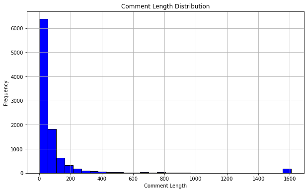

```python
import matplotlib.pyplot as plt

# Convert to pd df for plot
comments_pd = com_clean.select("comment_length").toPandas()

# Plot comment length distribution
plt.figure(figsize=(10, 6))
plt.hist(comments_pd["comment_length"], bins=30, color='blue', edgecolor='black')
plt.title("Comment Length Distribution")
plt.xlabel("Comment Length")
plt.ylabel("Frequency")
plt.grid(True)
plt.savefig("Users/zl483/fall-2023-reddit-project-team-30/data/plots/comment_length.png")
plt.show()
```

```python
comments_filtered = com_clean.filter(com_clean.comment_length <= 1000)
```

```
StatementMeta(f97af3eb-5425-4080-aefb-36c5e3ecc371, 15, 40, Finished, Available)
```

Count to see how many rows are left

```python
comments_filtered.count()
```

```
StatementMeta(f97af3eb-5425-4080-aefb-36c5e3ecc371, 15, 41, Finished, Available)
```

```
9809
```

```python
# save data to datastore
datastore = 'azureml://datastores/workspaceblobstore/paths'
sub_clean.write.parquet(f"{datastore}/sub_meme_aug.parquet")
comments_filtered.write.parquet(f"{datastore}/com_meme_aug.parquet")
```

```
StatementMeta(f97af3eb-5425-4080-aefb-36c5e3ecc371, 15, 42, Finished, Available)
```

## Generate Interesting graphs

Produce at least 5 interesting graphs about your dataset. Think about the dimensions that are interesting for your Reddit data! There are millions of choices. Make sure your graphs are connected to your business questions.

```python
# Read in filtered comments and submissions data from data store
datastore = 'azureml://datastores/workspaceblobstore/paths'
comments_filtered = spark.read.parquet(f"{datastore}/com_meme_aug.parquet")
submissions_filtered = spark.read.parquet(f"{datastore}/sub_meme_aug.parquet")
```

```
StatementMeta(f97af3eb-5425-4080-aefb-36c5e3ecc371, 15, 43, Finished, Available)
```

### 1. Score distributions

For reddit submissions, plot a histogram showing the distribution of scores that memes receive could provide insight into how many are hits or misses.

```python
# Get score column statistics to understand the distribution
submissions_filtered.describe(['score']).show()
```

```
StatementMeta(f97af3eb-5425-4080-aefb-36c5e3ecc371, 15, 44, Finished, Available)
```

```
+-------+-----------------+
|summary|            score|
+-------+-----------------+
|  count|            10000|
|   mean|           392.88|
| stddev|2814.164155373555|
|    min|                0|
|    max|            91319|
+-------+-----------------+
```

```python
# Convert the 'score' column to an RDD
scores_rdd = submissions_filtered.select('score').rdd.flatMap(lambda x: x)
```

```
StatementMeta(f97af3eb-5425-4080-aefb-36c5e3ecc371, 15, 45, Finished, Available)
```

```
StatementMeta(f97af3eb-5425-4080-aefb-36c5e3ecc371, 15, 46, Finished, Available)
```

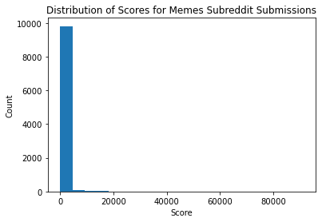

```python
from matplotlib import pyplot as plt
# Define the number of bins for the histogram
num_bins = 20

# Use RDD histogram to get the counts for each bin
histogram = scores_rdd.histogram(num_bins)

# The result is a tuple of two arrays
# The first array contains the bin edges
# The second array contains the count of scores in each bin
bin_edges = histogram[0]
counts = histogram[1]

# Plotting the histogram using matplotlib
plt.hist(bin_edges[:-1], bin_edges, weights=counts)
plt.xlabel('Score')
plt.ylabel('Count')
plt.title('Distribution of Scores for Memes Subreddit Submissions')
plt.savefig("Users/zl483/fall-2023-reddit-project-team-30/data/plots/meme_score.png")
plt.show()
```

This histogram would effectively categorize memes into various score ranges, making it easier to see how many memes are widely appreciated versus those that do not perform as well. By plotting the scores on the X-axis and the number of memes that fall into each score range on the Y-axis, one can quickly identify the most common score ranges, thus revealing trends in meme reception. Such a distribution could highlight if a large number of memes have low scores, suggesting they may not resonate with the audience, or if there is a significant number of high-scoring memes, indicating content that is very well-received. This analysis might also uncover any biases towards certain types of content or the presence of scoring anomalies. Ultimately, by examining the histogram's shape and spread, content creators and marketers can gain valuable insights into the types of memes that are likely to be hits or misses, thereby tailoring their strategies to better align with the preferences of the Reddit community.

### 2. Top authors

A bar chart displaying the top authors based on the number of memes posted or the cumulative score of their memes.

```python
from pyspark.sql import functions as F
# Group by 'author' and aggregate both count of posts and sum of scores
df_author_agg = submissions_filtered.groupBy('author') \
    .agg(
        F.count('author').alias('num_posts'),  # Count the number of posts
        F.sum('score').alias('total_score')  # Sum of scores for all posts
    )
```

```
StatementMeta(f97af3eb-5425-4080-aefb-36c5e3ecc371, 15, 47, Finished, Available)
```

```python
# Sort the DataFrame based on 'num_posts' or 'total_score' to find top authors
# You can switch between orderBy('num_posts') and orderBy('total_score') depending on your need
df_top_authors_by_posts = df_author_agg.orderBy(F.desc('num_posts'))
df_top_authors_by_score = df_author_agg.orderBy(F.desc('total_score'))

# Show top authors (limit to 10 for visualization purposes)
df_top_authors_by_posts.show(10)
df_top_authors_by_score.show(10)
```

```
StatementMeta(f97af3eb-5425-4080-aefb-36c5e3ecc371, 15, 48, Finished, Available)
```

```
+-----------------+---------+-----------+
|           author|num_posts|total_score|
+-----------------+---------+-----------+
|        [deleted]|     2828|     203264|
|      kyuthousand|      485|        485|
|          nikosh_|       26|         26|
|       luxusbuerg|       20|       3411|
|asilvertintedrose|       17|       4834|
|  ApricotSilly524|       16|       6684|
|         AlyaSell|       14|         14|
|     NetherTurtle|       13|       3234|
|LuvYouLongTimeAgo|       12|       4635|
|      LINKCAT1318|       12|        451|
+-----------------+---------+-----------+
only showing top 10 rows

+--------------+---------+-----------+
|        author|num_posts|total_score|
+--------------+---------+-----------+
|     [deleted]|     2828|     203264|
|     Bishwa254|        7|     193585|
|     johnlen1n|        5|     114613|
|  pantherghast|        4|      95779|
|     KLASHINOV|        4|      90562|
|RegularNoodles|        4|      76065|
|       REID-11|        8|      73790|
|    Ulquiorr4_|        7|      66951|
| AmayaILoveYou|        2|      66154|
| Due_Lynx_6855|        3|      60311|
+--------------+---------+-----------+
only showing top 10 rows
```

We noticed that the top 1 score and top 1 post author are deleted which is meaningless, so we choose top 2-11 authors from the tables.

```
StatementMeta(f97af3eb-5425-4080-aefb-36c5e3ecc371, 15, 49, Finished, Available)
```

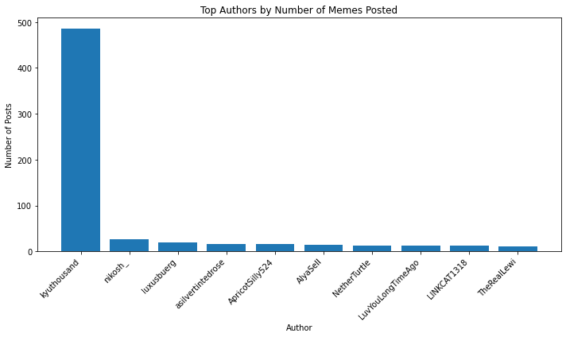

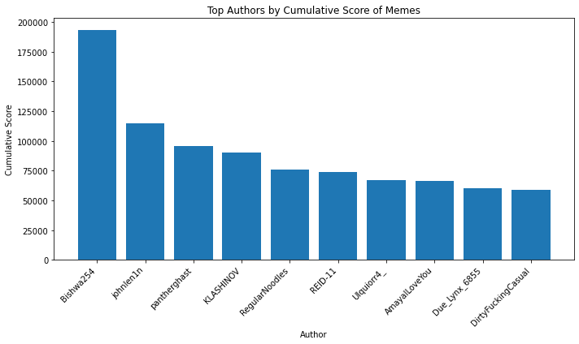

```python
from pyspark.sql.window import Window

# Collect the data to use in plotting, we collect the top 2-11 authors without any "deleted"
df_top_authors_by_posts = df_top_authors_by_posts.where(df_top_authors_by_posts.author != '[deleted]')
df_top_authors_by_score = df_top_authors_by_score.where(df_top_authors_by_score.author != '[deleted]')

top_authors_posts_data = df_top_authors_by_posts.limit(10).toPandas()
top_authors_score_data = df_top_authors_by_score.limit(10).toPandas()

# Plotting the top authors by post count
plt.figure(figsize=(10, 6))
plt.bar(top_authors_posts_data['author'], top_authors_posts_data['num_posts'])
plt.xlabel('Author')
plt.ylabel('Number of Posts')
plt.title('Top Authors by Number of Memes Posted')
plt.xticks(rotation=45, ha='right')
plt.tight_layout()
plt.savefig("Users/zl483/fall-2023-reddit-project-team-30/data/plots/top_author_meme.png")
plt.show()

# Plotting the top authors by score
plt.figure(figsize=(10, 6))
plt.bar(top_authors_score_data['author'], top_authors_score_data['total_score'])
plt.xlabel('Author')
plt.ylabel('Cumulative Score')
plt.title('Top Authors by Cumulative Score of Memes')
plt.xticks(rotation=45, ha='right')
plt.tight_layout()
plt.savefig("Users/zl483/fall-2023-reddit-project-team-30/data/plots/top_author_cumu_score.png")
plt.show()
```

We can see in the two graphs, after removing invalid and pointless rows, the results of top authors are different. The author kyuthousand post the most submissions in the time period we have chosen. However, he does not appear on the top authors order by cumulative score of memes. This can show that more posts published does not mean that the posts are more popular, and the most popular authors selected based on the two methods are completely different. Authors don't get higher scores by posting more posts, and this is a revelation to all authors on reddit to improve the quality of their post content to increase the score of their posts.

### 3. Over-18 Content Analysis:

A pie chart to show the percentage of memes that are marked as over-18. Comparing the average score and comments for over-18 memes against those that are not.

```python
from pyspark.sql.functions import avg, count, when, col

# Calculate the count of over-18 and not over-18 memes
over_18_count = submissions_filtered.groupBy('over_18').agg(count('*').alias('count'))

# Calculate the average score and comments for over-18 and not over-18 memes
avg_stats = submissions_filtered.groupBy('over_18').agg(
    avg('score').alias('average_score'),
    avg('num_comments').alias('average_comments')
)

# Now let's collect these statistics to use with matplotlib
over_18_data = over_18_count.toPandas()
avg_stats_data = avg_stats.toPandas()
```

```
StatementMeta(f97af3eb-5425-4080-aefb-36c5e3ecc371, 15, 50, Finished, Available)
```

```
StatementMeta(f97af3eb-5425-4080-aefb-36c5e3ecc371, 15, 51, Finished, Available)
```

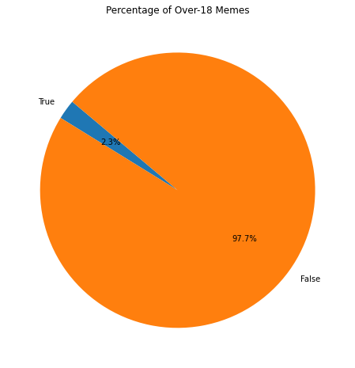

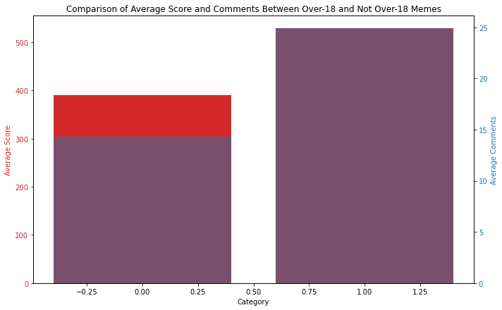

```python
# Create a pie chart for over-18 memes
plt.figure(figsize=(8, 8))
plt.pie(over_18_data['count'], labels=over_18_data['over_18'], autopct='%1.1f%%', startangle=140)
plt.title('Percentage of Over-18 Memes')
plt.savefig("Users/zl483/fall-2023-reddit-project-team-30/data/plots/over18_meme.png")
plt.show()

# Create a bar chart for average scores and comments
fig, ax1 = plt.subplots(figsize=(10, 6))

# Create bar chart for average score
ax1.set_xlabel('Category')
ax1.set_ylabel('Average Score', color='tab:red')
ax1.bar(avg_stats_data['over_18'], avg_stats_data['average_score'], color='tab:red', label='Average Score')
ax1.tick_params(axis='y', labelcolor='tab:red')

# Instantiate a second y-axis sharing the same x-axis
ax2 = ax1.twinx()
ax2.set_ylabel('Average Comments', color='tab:blue')
ax2.bar(avg_stats_data['over_18'], avg_stats_data['average_comments'], color='tab:blue', alpha=0.5, label='Average Comments')
ax2.tick_params(axis='y', labelcolor='tab:blue')

# Add a legend and a title to the plot
fig.tight_layout()
plt.title('Comparison of Average Score and Comments Between Over-18 and Not Over-18 Memes')
plt.savefig("Users/zl483/fall-2023-reddit-project-team-30/data/plots/yes_not_18.png")
plt.show()
```

The pie chart shows the percentage comparison between over-18 content and non over-18 contents. We use the comparisons here to initially identify the ratio of the two types of content, which will be useful for later predictive modeling of over-18 content.

### 4. Engagement Analysis:

A scatter plot correlating the number of comments to the score of memes could show if more engaging memes tend to be scored higher.

```
StatementMeta(f97af3eb-5425-4080-aefb-36c5e3ecc371, 15, 52, Finished, Available)
```

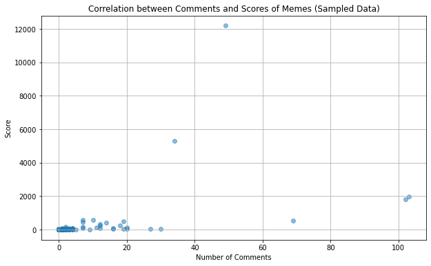

```python
from pyspark.sql.functions import rand  # import the required function

# Sample approximately 100 rows from the DataFrame (without replacement)
sampled_submissions = submissions_filtered.orderBy(rand()).limit(100)

# Now you can convert this to a Pandas DataFrame to use with Matplotlib
sampled_submissions_pandas = sampled_submissions.toPandas()

# And now proceed with your plotting as before
num_comments_sampled = sampled_submissions_pandas['num_comments']
scores_sampled = sampled_submissions_pandas['score']

plt.figure(figsize=(10, 6))
plt.scatter(num_comments_sampled, scores_sampled, alpha=0.5)

plt.title('Correlation between Comments and Scores of Memes (Sampled Data)')
plt.xlabel('Number of Comments')
plt.ylabel('Score')

plt.grid(True)
plt.savefig("Users/zl483/fall-2023-reddit-project-team-30/data/plots/num_of_comments.png")
plt.show()
```

## Generating summary tables

Produce at least 3 interesting summary tables about your dataset. You can decide how to split up your data into categories, time slices, etc. There are infinite ways you can make summary statistics. Be unique, creative, and interesting!

### 1. Daily Activity Summary:

Table listing each day with the total number of memes posted, average score, median score, total number of comments, and average number of comments.

```python
from pyspark.sql import functions as F
from pyspark.sql import SparkSession

# Cast 'created_utc' to a date format
submissions_filtered = submissions_filtered.withColumn(
    'date',
    F.col('created_utc').cast('date')
)

# Group by the 'date' column and calculate the required statistics
daily_activity_summary = submissions_filtered.groupBy('date') \
    .agg(
        F.count('author').alias('total_memes_posted'),
        F.avg('score').alias('average_score'),
        F.expr('percentile_approx(score, 0.5)').alias('median_score'),
        F.sum('num_comments').alias('total_comments'),
        F.avg('num_comments').alias('average_comments')
    ) \
    .orderBy('date')  # Order by date for readability

# Show the summary table
daily_activity_summary.show(5)  # Show only the first 5 rows for brevity
```

```
StatementMeta(f97af3eb-5425-4080-aefb-36c5e3ecc371, 15, 53, Finished, Available)
```

```
+----------+------------------+------------------+------------+--------------+------------------+
|      date|total_memes_posted|     average_score|median_score|total_comments|  average_comments|
+----------+------------------+------------------+------------+--------------+------------------+
|2022-08-01|               372|397.73924731182797|           3|          3376| 9.075268817204302|
|2022-08-02|               523| 410.8929254302103|           5|          6209| 11.87189292543021|
|2022-08-03|               614|302.69869706840393|           8|          5131| 8.356677524429967|
|2022-08-04|               584| 230.4914383561644|           9|          7854|13.448630136986301|
|2022-08-05|               481| 358.5446985446985|          13|          4762| 9.900207900207901|
+----------+------------------+------------------+------------+--------------+------------------+
only showing top 5 rows
```

### 2. Title Length Analysis:

A table showing the correlation between the length of the meme title and its popularity, categorized by average score and comment count.

```python
from pyspark.sql import functions as F

# Add a new column for title length
submissions_filtered = submissions_filtered.withColumn(
    'title_length',
    F.length('title')
)

# Aggregate the data to find average score and comment count for each title length
title_length_analysis = submissions_filtered.groupBy('title_length') \
    .agg(
        F.avg('score').alias('average_score'),
        F.avg('num_comments').alias('average_comments')
    ) \
    .orderBy('title_length')  # Order by title length for readability

# Calculate the correlation between title length and average score
correlation_score = submissions_filtered.stat.corr('title_length', 'score')

# Calculate the correlation between title length and average number of comments
correlation_comments = submissions_filtered.stat.corr('title_length', 'num_comments')

# Show the analysis table
title_length_analysis.show()

# Print out the correlation results
print(f"Correlation between title length and score: {correlation_score}")
print(f"Correlation between title length and number of comments: {correlation_comments}")
```

```
StatementMeta(f97af3eb-5425-4080-aefb-36c5e3ecc371, 15, 54, Finished, Available)
```

```
+------------+------------------+------------------+
|title_length|     average_score|  average_comments|
+------------+------------------+------------------+
|           1|1.0185185185185186|1.0833333333333333|
|           2|1.0126582278481013|1.1012658227848102|
|           3|             0.992|             1.072|
|           4|0.9877300613496932|1.0429447852760736|
|           5|0.9887005649717514| 1.073446327683616|
|           6|               1.0|1.0333333333333334|
|           7|162.36559139784947| 9.666666666666666|
|           8|373.05464480874315|10.180327868852459|
|           9|228.67782426778243|24.405857740585773|
|          10| 615.8828451882845| 9.589958158995817|
|          11|           530.604|             23.22|
|          12|380.13028169014086|               7.0|
|          13| 606.4620938628159|13.606498194945848|
|          14| 316.6784565916399|15.620578778135048|
|          15|485.30743243243245|10.030405405405405|
|          16| 623.8301282051282|16.493589743589745|
|          17|1080.2420382165606|26.738853503184714|
|          18| 399.2905198776758|11.128440366972477|
|          19|323.91373801916933| 22.84664536741214|
|          20|463.89261744966444|15.389261744966444|
+------------+------------------+------------------+
only showing top 20 rows

Correlation between title length and score: -0.010717859275810053
Correlation between title length and number of comments: 0.007704428154268617
```

### 3. Meme Popularity by Time of Day:

Summarize which time of the day receives the highest engagement by showing the average score and number of comments for memes posted during different time blocks (e.g., morning, afternoon, evening, late night).

```python
from pyspark.sql import functions as F
from pyspark.sql.types import StringType

# Function to categorize time of day
def get_time_of_day(hour):
    if 5 <= hour < 12:
        return 'Morning'
    elif 12 <= hour < 17:
        return 'Afternoon'
    elif 17 <= hour < 21:
        return 'Evening'
    else:
        return 'Late Night'

# Register the function as a UDF (user-defined function)
get_time_of_day_udf = F.udf(get_time_of_day, StringType())

# Extract the hour from created_utc (assuming it's already a timestamp) and create a new column for time of day
submissions_filtered = submissions_filtered.withColumn(
    'hour',
    F.hour('created_utc')
).withColumn(
    'time_of_day',
    get_time_of_day_udf('hour')
)

# Group by the time_of_day and calculate average score and comments
meme_popularity_time_of_day = submissions_filtered.groupBy('time_of_day') \
    .agg(
        F.avg('score').alias('average_score'),
        F.avg('num_comments').alias('average_comments')
    ) \
    .orderBy('time_of_day')  # Order by time_of_day for readability

# Show the analysis table
meme_popularity_time_of_day.show()
```

```
StatementMeta(f97af3eb-5425-4080-aefb-36c5e3ecc371, 15, 55, Finished, Available)
```

```
+-----------+------------------+------------------+
|time_of_day|     average_score|  average_comments|
+-----------+------------------+------------------+
|  Afternoon| 417.9219035997559|15.858450274557658|
|    Evening|321.10539845758353| 15.54241645244216|
| Late Night|299.36308552784897|12.465858774178512|
|    Morning| 628.0983529411765| 16.91764705882353|
+-----------+------------------+------------------+
```

## Creating New Variables

Use data transformations to make AT LEAST 3 new variables that are relevant to your business questions. We cannot be more specific because this depends on your project and what you want to explore!

### 1. Comments Sentiment Score:

```python
!pip install textblob
```

```
StatementMeta(f97af3eb-5425-4080-aefb-36c5e3ecc371, 10, 15, Finished, Available)
```

```python
from textblob import TextBlob
from pyspark.sql.functions import udf
from pyspark.sql.types import FloatType

# UDF to compute sentiment polarity
def sentiment_score(text):
    return TextBlob(text).sentiment.polarity

sentiment_udf = udf(sentiment_score, FloatType())

# Add a new column for sentiment score
comments_filtered = comments_filtered.withColumn('comment_sentiment', sentiment_udf(comments_filtered['body']))

# Show some results
comments_filtered.select('body', 'comment_sentiment').show()
```

```
StatementMeta(f97af3eb-5425-4080-aefb-36c5e3ecc371, 15, 56, Finished, Available)
```

```
+--------------------+-----------------+
|                body|comment_sentiment|
+--------------------+-----------------+
|Typically your te...|       0.05925926|
|Wait am wrong did...|             -0.5|
|Yea but some cons...|              0.0|
|I actually think ...|       0.04090909|
|Thats why I use N...|             0.05|
|                  🤔|              0.0|
|I have the opposi...|              0.0|
|           Its 18:02|              0.0|
|I’m Christian and...|              0.1|
|  *aims to the left*|              0.0|
|Popcorn anyone? P...|              0.0|
|To the best of my...|              1.0|
|I read somewhere ...|              0.0|
|Yeah. Not even li...|             -0.1|
|no, just some dis...|              0.0|
|You're being crin...|      0.042857144|
|Because the batte...|              0.0|
|“Laughs in unlimi...|              0.0|
| Who were you again?|              0.0|
|           [removed]|              0.0|
+--------------------+-----------------+
only showing top 20 rows
```

### 2. Post Engagement Rate:

This could be calculated as the number of comments plus the score (as a proxy for the number of upvotes) divided by the number of views (if view count is available). If view count is not available, a standard engagement rate with respect to comments and score can still be insightful.

```python
from pyspark.sql.functions import max
from pyspark.sql.functions import col

# Calculate max values for normalization
max_score = submissions_filtered.agg(max(col('score'))).collect()[0][0]
max_comments = submissions_filtered.agg(max(col('num_comments'))).collect()[0][0]

# Add a new column with the normalized engagement rate
submissions_filtered = submissions_filtered.withColumn(
    'normalized_engagement_rate',
    (col('num_comments') / max_comments + col('score') / max_score)
)

# Show the updated DataFrame
submissions_filtered.select('title', 'num_comments', 'score', 'normalized_engagement_rate').show()
```

```
StatementMeta(f97af3eb-5425-4080-aefb-36c5e3ecc371, 15, 57, Finished, Available)
```

```
+--------------------+------------+-----+--------------------------+
|               title|num_comments|score|normalized_engagement_rate|
+--------------------+------------+-----+--------------------------+
|It's not being ea...|           3|   33|      0.001191705481798...|
|I can't take anym...|          10|  157|      0.004487030916980886|
|When people ask m...|           1|    1|      2.877289242192506E-4|
|No, I don't think...|           0|    1|      1.095062363801618...|
| Every.God.Damn.Time|           0|    1|      1.095062363801618...|
|And sent him back...|           0|    1|      1.095062363801618...|
|but how can this be?|           3|    1|      8.412855253817195E-4|
|        Don’t do it.|          14|   36|      0.004269118659105865|
|What are you look...|           1|   25|       5.50543891531639E-4|
|They just don't m...|           0|   15|      1.642593545702427...|
|YES OF COURSE I K...|           4|    8|      0.001194718191429...|
|         I made this|           2|    1|       5.64507224800485E-4|
|      extratone rips|           0|    1|      1.095062363801618...|
|The fuck you mean...|           4|   28|      0.001413730664189...|
|to the peoples wh...|           4|   52|      0.001676545631501...|
|              Sorry.|           1|    1|      2.877289242192506E-4|
|It belongs in a m...|           2|   10|      6.630628375426307E-4|
|Stages of watchin...|           3|   19|      0.001038396750866...|
|@futurenews69 😜 ...|           0|    1|      1.095062363801618...|
|@futurenews69 😜 ...|           0|    1|      1.095062363801618...|
+--------------------+------------+-----+--------------------------+
only showing top 20 rows
```

### 3. Post Length

Generating a new column that shows the number of comments contents.

```python
from pyspark.sql.functions import length

# Assuming 'submissions_filtered' is your DataFrame and 'selftext' contains the text of the posts
comments_filtered = comments_filtered.withColumn('comment_length', length(comments_filtered['body']))

# Show the updated DataFrame
comments_filtered.select('body', 'comment_length').show()
```

```
StatementMeta(f97af3eb-5425-4080-aefb-36c5e3ecc371, 15, 58, Finished, Available)
```

```
+--------------------+--------------+
|                body|comment_length|
+--------------------+--------------+
|Typically your te...|           156|
|Wait am wrong did...|            29|
|Yea but some cons...|            48|
|I actually think ...|           530|
|Thats why I use N...|            67|
|                  🤔|             1|
|I have the opposi...|           139|
|           Its 18:02|             9|
|I’m Christian and...|            39|
|  *aims to the left*|            18|
|Popcorn anyone? P...|            24|
|To the best of my...|            25|
|I read somewhere ...|            46|
|Yeah. Not even li...|           165|
|no, just some dis...|            82|
|You're being crin...|            37|
|Because the batte...|            54|
|“Laughs in unlimi...|            26|
| Who were you again?|            19|
|           [removed]|             9|
+--------------------+--------------+
only showing top 20 rows
```

## Regex Searches for interesting keywords

Implement regex searches for specific keywords of interest to produce dummy variables and then make statistics that are related to your business questions.

key words list ["funny", "joke", "humor"]

For statistics, I want to calculate the total number of occurrences of each keyword and the average score for posts containing each keyword

```python
from pyspark.sql.functions import col, when, sum as sql_sum

# List of keywords
keywords = ["funny", "joke", "humor"]

# Create dummy variables for each keyword
for keyword in keywords:
    submissions_filtered = submissions_filtered.withColumn(f"{keyword}_dummy", col("title").rlike(f"(?i)\\b{keyword}\\b").cast("integer"))

# Now, submissions_filtered will have new columns: 'funny_dummy', 'joke_dummy', 'humor_dummy'
# with 1 indicating presence of the keyword and 0 otherwise.

# For statistics, I want to calculate the total number of occurrences of each keyword
# and the average score for posts containing each keyword
statistics_df = submissions_filtered.select(
    *[sql_sum(col(f"{keyword}_dummy")).alias(f"{keyword}_count") for keyword in keywords],
    *[sql_sum(col(f"{keyword}_dummy") * col("score")).alias(f"{keyword}_score_total") for keyword in keywords]
)

# Calculate average score for each keyword
for keyword in keywords:
    statistics_df = statistics_df.withColumn(f"{keyword}_avg_score", col(f"{keyword}_score_total") / col(f"{keyword}_count"))

statistics_df.show()
```

```
StatementMeta(f97af3eb-5425-4080-aefb-36c5e3ecc371, 15, 59, Finished, Available)
```

```
+-----------+----------+-----------+-----------------+----------------+-----------------+------------------+----------------+------------------+
|funny_count|joke_count|humor_count|funny_score_total|joke_score_total|humor_score_total|   funny_avg_score|  joke_avg_score|   humor_avg_score|
+-----------+----------+-----------+-----------------+----------------+-----------------+------------------+----------------+------------------+
|         66|        23|          9|            13137|           17441|             1309|199.04545454545453|758.304347826087|145.44444444444446|
+-----------+----------+-----------+-----------------+----------------+-----------------+------------------+----------------+------------------+
```

### Create DF

For this project, we are trying to use the post time

```python
# Rename the "subreddit" column in comments_filtered to "comments_subreddit"
comments_filtered = comments_filtered.withColumnRenamed("subreddit", "comments_subreddit")

# Perform the join using the link_id and id columns
meme_joined_df = comments_filtered.join(submissions_filtered, comments_filtered["link_id"] == submissions_filtered["id"], "inner")
```

```
StatementMeta(f97af3eb-5425-4080-aefb-36c5e3ecc371, 15, 61, Finished, Available)
```

```python
#sub_clean.write.parquet(f"{datastore}/sub_meme_aug.parquet")
```

### 3 NLP Business Goals

#### 1. Sentiment Analysis of Subreddit Comments

**Business Goal:** Gauge the overall sentiment of subreddits to tailor communication strategies and improve user experience.

**Technical Proposal:** Use sentiment analysis to classify comments into positive, negative, and neutral categories. Analyze the sentiment scores across different times and events to see how user sentiment changes in reaction to external factors.

#### 2. Content Quality Assessment

**Business Goal:** Enhance user retention by ensuring high-quality content within subreddits.

**Technical Proposal:** Build an NLP model to score the quality of posts based on readability, informativeness, and engagement potential. Use regression analysis to predict the quality score and provide feedback for content creators.

#### 3. Automated Topic Tagging for Posts

**Business Goal:** Improve searchability and discoverability of subreddit content through automated topic tagging.

**Technical Proposal:** Train a multi-class classification model on the post titles and bodies to assign topic tags automatically. Use TF-IDF or word embeddings for feature extraction and evaluate different classifiers for best performance.

#### 1. Predictive Analysis for Subreddit Growth

**Business Goal:** Forecast subreddit community growth to optimize resource allocation and community management efforts.

**Technical Proposal:** Leverage historical subreddit data to build time-series forecasting models that predict subscriber and post volume trends. Compare models like ARIMA, SARIMA, and LSTM for accuracy in capturing seasonal patterns and long-term trends. Implement model validation using metrics like MAE and RMSE to ensure reliable predictions for effective planning and strategy development.

#### 2. Toxic Comment Identification

**Business Goal:** Enhance online discourse quality by promptly detecting and mitigating toxic comments to foster a positive community environment.

**Technical Proposal:** Develop an NLP-based classification system trained on a comprehensive dataset with annotations for various levels of toxicity, including harassment, hate speech, and abusive language. Utilize advanced text representation techniques like word embeddings (Word2Vec, BERT) to capture semantic meanings and contextual nuances. Apply machine learning algorithms, possibly a combination of CNNs and RNNs, to effectively distinguish toxic comments, and incorporate model explainability to aid moderators in understanding decision rationales.

#### 3. Predictive Analysis for Subreddit Growth

**Business Goal:** Determine the trajectory of subreddit expansion to strategically guide marketing and community management efforts, ensuring optimal engagement and content delivery.

**Technical Proposal:** Implement advanced time-series analysis techniques, such as ARIMA or LSTM networks, to model the growth trends of subreddit memberships and content generation. Integrate sentiment analysis to weigh the impact of community sentiment on growth rates. Design the system to ingest historical data and real-time interaction metrics to refine forecasts continuously, thereby providing subreddit administrators with actionable insights for dynamic resource allocation.